# Predicting the 2020 NBA MVP

### Introduction

We chose to focus on basketball because we were all interested in sports and sports is a topic that contains a vast amount of data. We decided to narrow our focus down to a particular aspect of sports. We are curious about the best players and the factors that make them so good, so we decided to explore data about the annual Most Valuable Player, namely trends in MVP’s of the National Basketball Association. In this project, we plan to answer the question: What will be the features of the 2020 NBA MVP? Our answer and prediction for the 2020 MVP focuses on three parts. Firstly, we calculated the probability for our new MVP being either positions,and we also analysed the playing time and three-point rate for the MVP. Secondly, we used a 95% confidence level and linear regression models to get the range of Height and Weight for the MVP being either positions. Lastly, we used a normal distribution approximation and a 95% confidence level hypothesis test to find out the contribution that the MVP can produce for the team, namely, win shares of the season.

### Background

> About the raw data:

We combined three different datasets, all about NBA MVPs. The first one, called NBA finals and mvps (renamed to mvp_attribute.csv), was collected by a basketball fan. This dataset contains the yearly NBA finals and NBA regular-season MVPs, including the champion of western and eastern conferences, the vice NBA champion, the NBA champion, and the MVP’s physical info such as height, weight, etc. The second dataset and third dataset come from Basketball Reference, which contains official data records for the NBA. This dataset, originally called NBA winners, was renamed to mvp_satats.csv. This dataset contains data about each mvp of each year and their basketball ability. The third dataset, called players, contains the basic data of all NBA players, not only MVPs. It gives information such as their college and birth place. By matching the name of MVPs, we extrach the MVP info that we need.

> The MVP dataset we finally use:

The data we are using is all based on the MVP of the last 60 or so seasons. The data dives deeper into each player who won the award, giving statistics such as height, field goal percentage, and three-point percentage. Some of the statistics may seem hard to understand for people who don’t watch basketball. MP means minutes played per each game. One of the easier ones to encode is PTS, which is points scored per game. TRB is total rebounds per game, AST is total assists per game (an assist is when a player passes the ball to the scorer). FG% is the percent of total shots made, whereas 3PT% is the percentage of shots made behind the 3 point arc. FT% is the total percentage of free throws made. Some less common stats are WS and WS/48 which are the estimated number of wins contributed by a certain player and estimated number of wins contributed per 48 minutes respectively. Something to keep in mind is that the three point line wasn’t added until the beginning of the 1979 season which explains the missing values in some columns.

> Data citation:

“NBA Finals and MVPs - Dataset by Datatouille.” Data.world, 31 Oct. 2018, data.world/datatouille/nba-finals-and-mvps.

“NBA MVP & ABA Most Valuable Player Award Winners.” Basketball, www.basketball-reference.com/awards/mvp.html.

Goldstein, Omri. “NBA Players Stats since 1950.” Kaggle, 27 Apr. 2018, www.kaggle.com/drgilermo/nba-players-stats#Seasons_Stats.csv.

> Some focus:

Our first focus is the trend in MVP’s positions over time. Due to the trend of MVP’s positions over time, we also see a trend of incresed emphasis on three point shooting, a player’s ability to score a three point shot. Our second focus is on data about each MVP’s physical information: Their height and weight in relation to the year they win the MVP. Third is how much the mvp contributed to the team. We focused on win shares to see whether the MVP deserves the award.

### Analysis

> Firstly,we want to inspect the change in the strategical role of MVP’s over the past 60 years, along with what skills the MVP will exhibit on the court. To do this, we will investigate the minutes played per game and the trend of three-point shooting rate and positions of MVP’s over time.

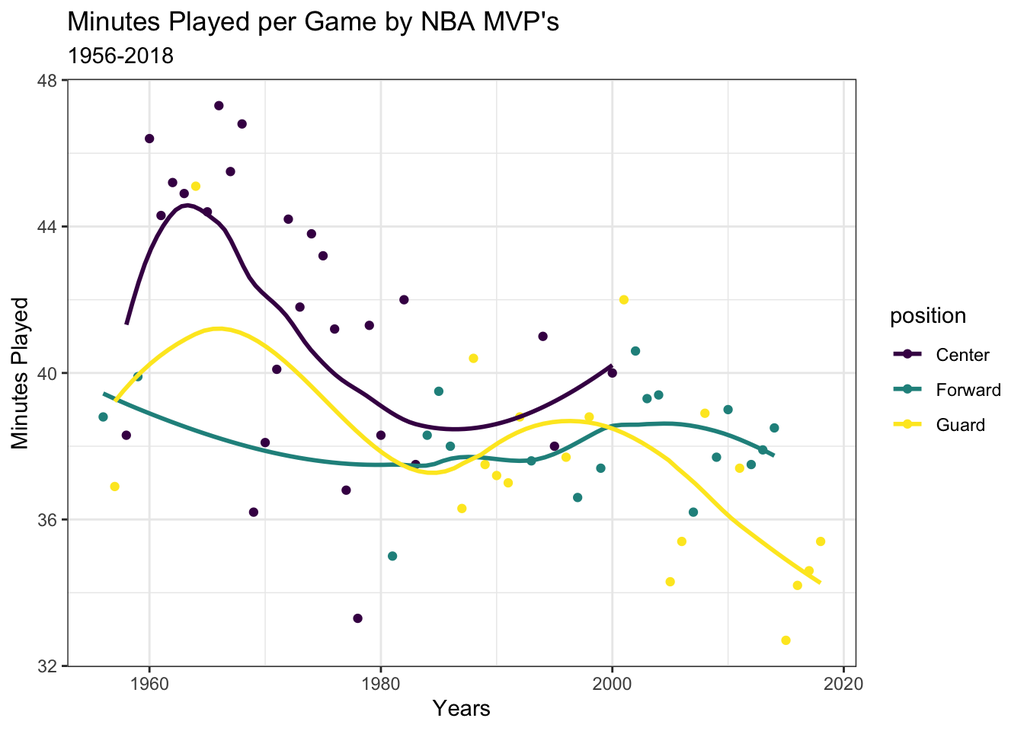

We can conclude that overall the minutes played for MVP’s has gone down over time.Over time, it has become more likely that a forward or guard wins MVP, and less likely that a center wins MVP.For forwards, minutes played by MVP’s has stayed fairly constant, however there is a general downward trend for guards and centers

> To find out the reason behind this, we continuted to research on the three-point rate of MVPs. We only have data after 1979 because NBA did not add the three-point line until 1979.

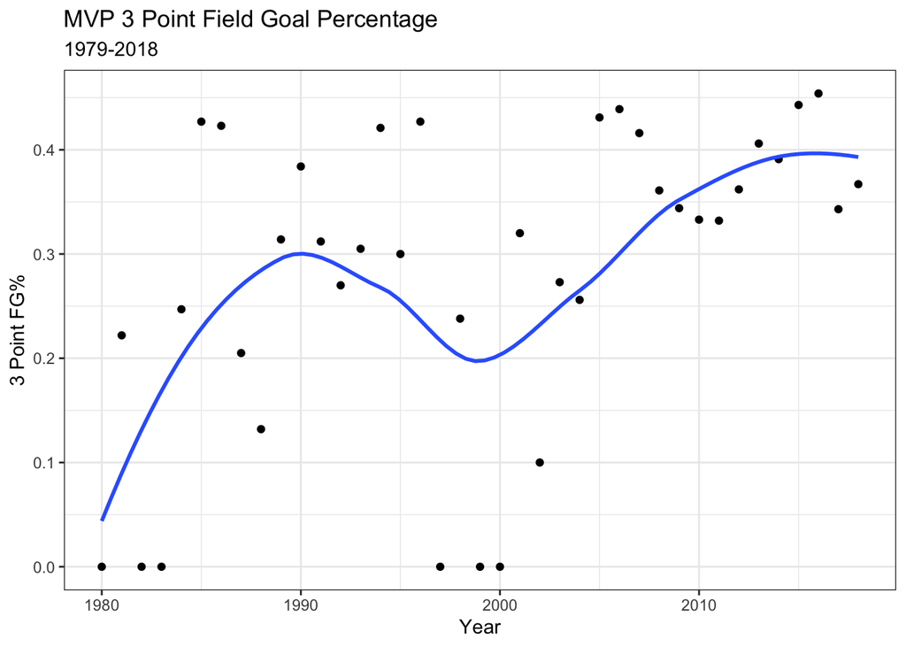

```
## # A tibble: 3 x 2
##   position     TP
##   <chr>     <dbl>
## 1 Center   0.0277
## 2 Forward  0.250
## 3 Guard    0.304
```

This graph shows that the MVP’s three point percentage is definitely trending upwards. The statistic of three point percentage was not recognized by the NBA until the 1979-1980 season, which is why the graph starts there. Three point field goal percentage is much higher for guards and forwards than it is for centers. Since it is become more likely that the MVP will be a guard or forward, and less likely that it will be a center, we have evidence that the three point percentage is becoming more important in determining the MVP.

According to this information, we predict that our 2020 MVP will be either a guard or a forward. We plotted the occurances to find out the probability of 2020 MVP being a guard or a forward.

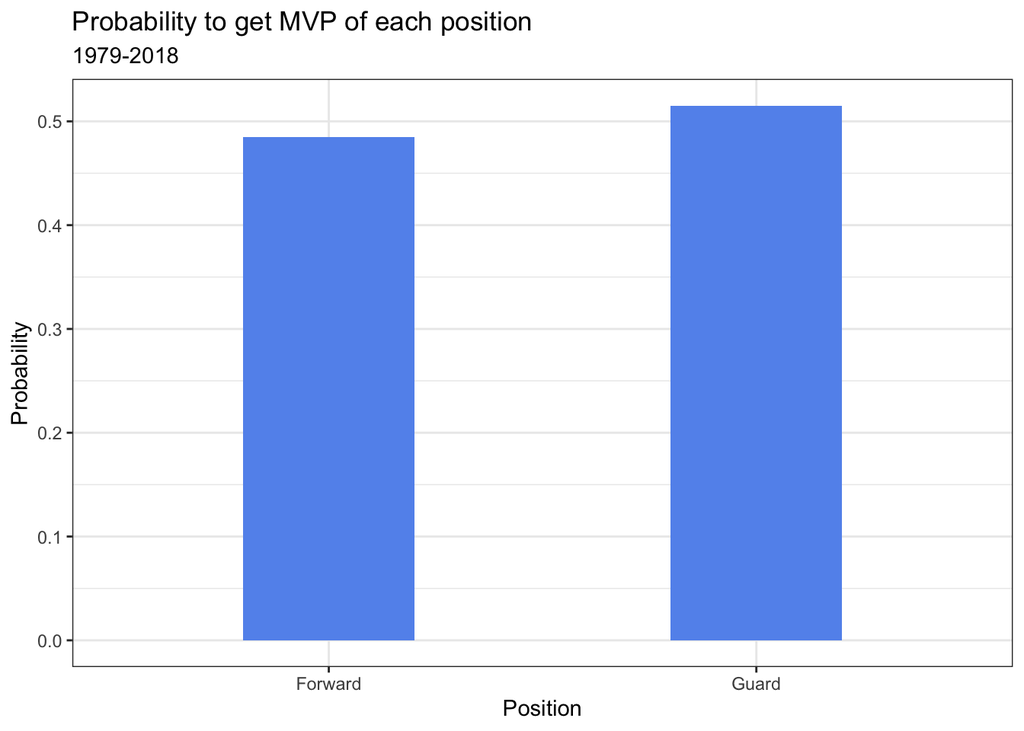

Thus, we could get the probability of 2020 MVP being a guard is 51.51% and 48.48% for being a forward.

> From these figures, we can get that, our new MVP will have 51.51% chance to be a guard and 48.48% chance to be a forward. He will also have 38% three-point rate, and if our new MVP is a forward, he will play about 38 minutes per game and if he is a guard, he will play 35 minutes per game.

> Secondly,we want to know the new MVP’s physical features, namely height and weight.

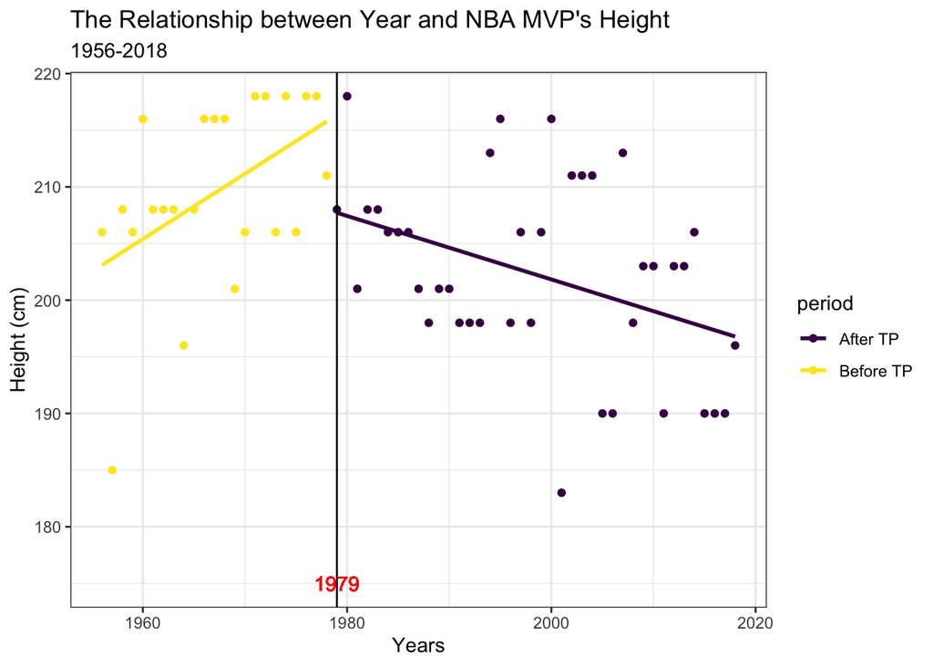

From this figure and our previous conclusion, we found a decresing trend of MVP’s height since 1979. We conclude that as the result of the position swaps from centers to forwards and guards. We decided to investigate the relationship between the years and MVP’s Heights after 1979 for fowards and guards.

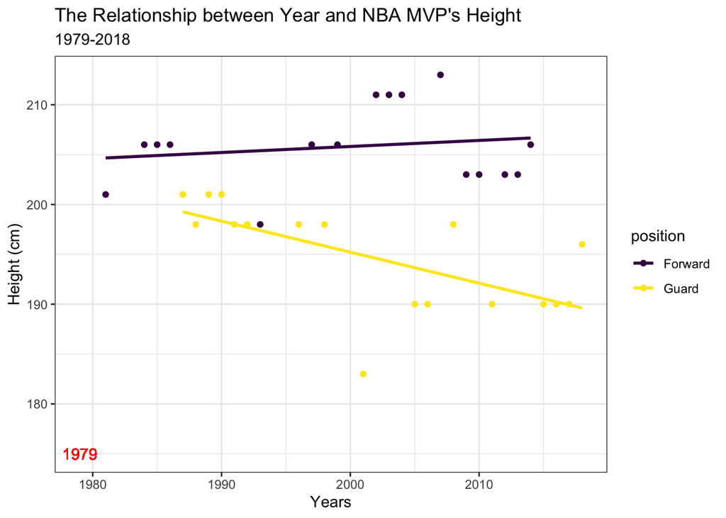

> After looking into the data. we find that there is a quite strong trend that year and height,height and weight have liner relationships. We then decide use a linear regression model to find the size of our new MVP for either being a forward or guard.

Now we want to test the residuals to make sure those residuals are follow an approximate normal distribution and no strong pattern for the residuals i.e residuals should resemble random noise.

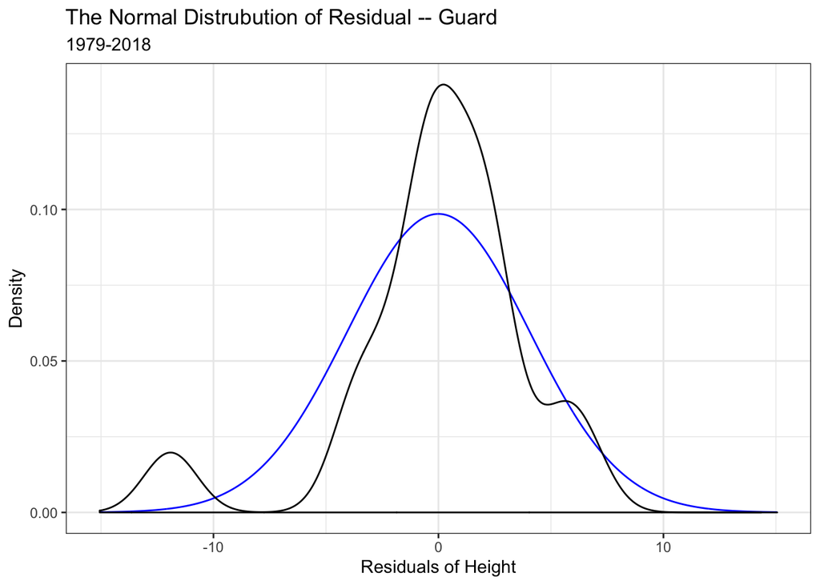

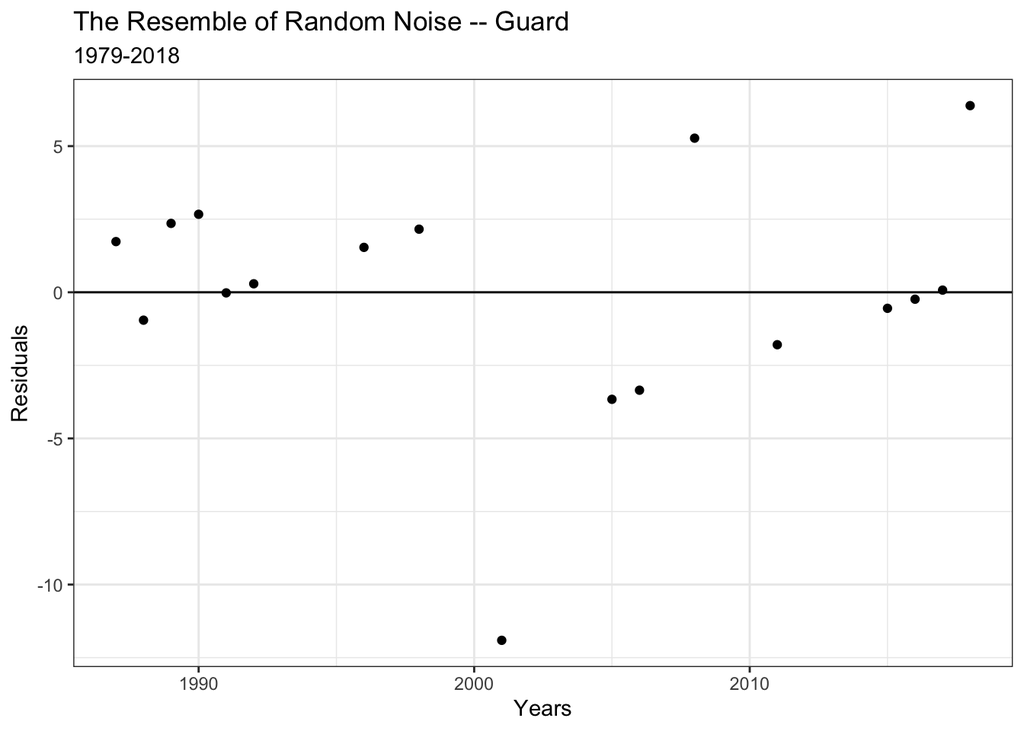

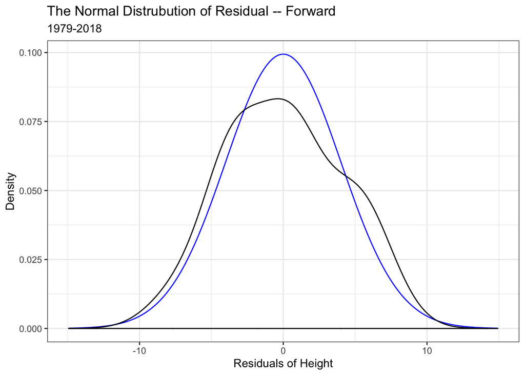

[figure not shown]

> Next, we want to do the same thing for the relationships between height and weight for our MVP.

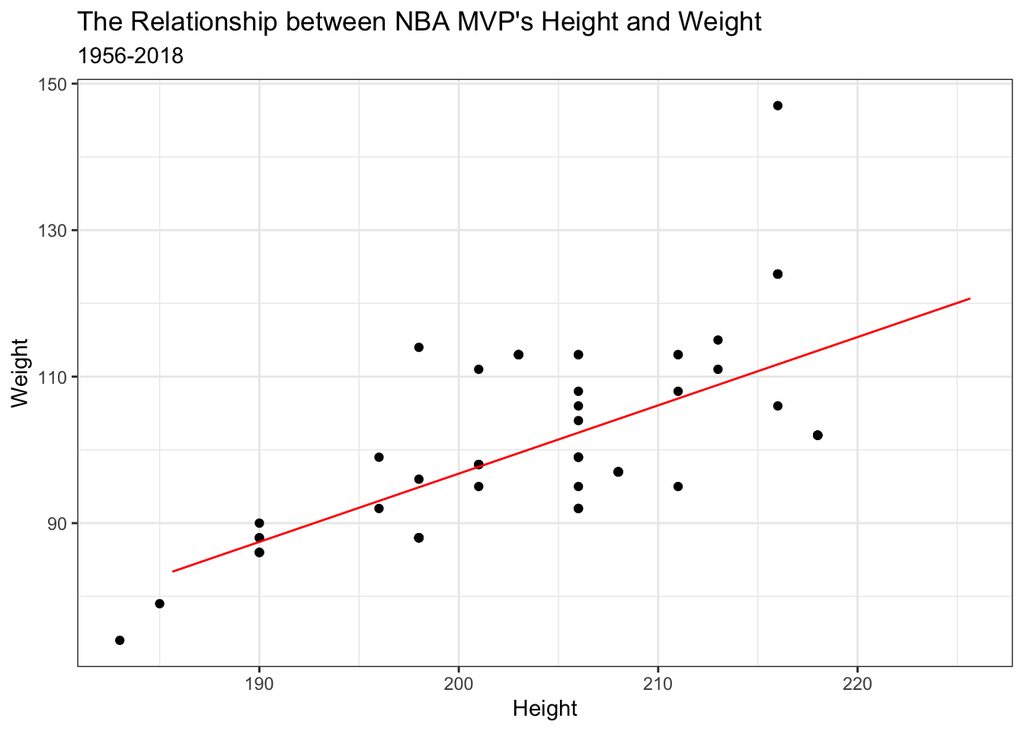

$$Weight = 0.93 * Height - 89.25$$

Thus, our 95% confidence interval for guards would be 87kg to 95kg and for forwards would be 98kg to 107kg.

> Lastly, we want to know how MVPs contribute to the team. After looking into the data, we found a variable that is called Win Shares will help with prediction in the analysis.

> Win Shares is a metric that estimates how many wins that a player produces for a team. The MVP is definetly the greatest win contributor within a team. After we plotted the density of Win Shares for every MVP we found that it can be fitted into a normal distribution. We can also print out the sample mean and standard error.

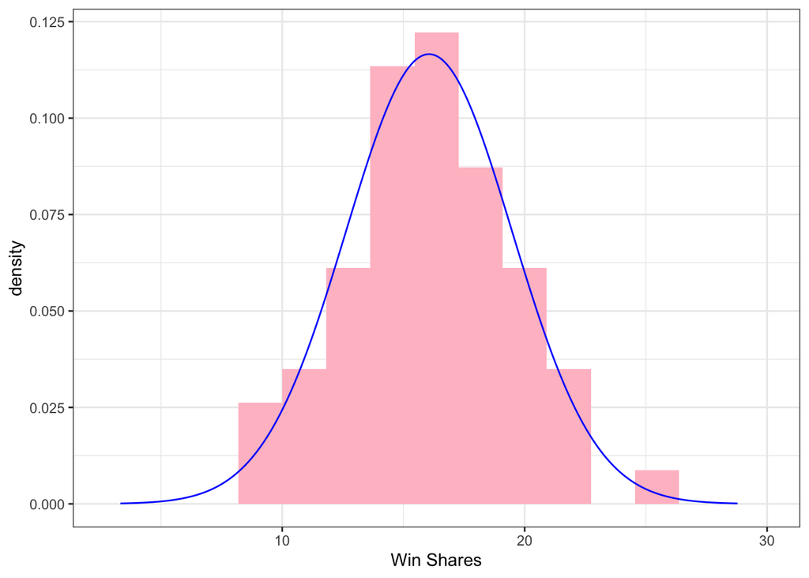

```
## # A tibble: 2 x 2
##   stat     WS
##   <chr> <dbl>
## 1 mean  16.1
## 2 se     3.42
```

These mvps we have is a sample n of 63. Since n > 30 accroding to CLT, we will assume it will be a normal distribution and the sample mean is also the propotion mean. We now can conduct a hypothesis test to find if our predicted MVP’s Win Share will exceed 20.5(Which is a quarter of number whole season’s games ). We use a confidence level of 95%.

The data is:

- $n=63$
- $\mu_0=16.1$
- $s=3.42$
- $X=20.5$
1. Model:

We apply the hypothesis model for samples here.
$$X\sim \text{Normal}(\mu_0,\frac{s}{\sqrt{n}})$$

2. State hypotheses:

$$H_0: X >= 20.5 \\
H_a: X < 20.5$$

3.$Z_\alpha = qnorm(97.5\%)$ The confidence level would be $[\mu_0 - z_\alpha\frac{s}{\sqrt{n}}, \mu_0 + z_\alpha\frac{s}{\sqrt{n}}]$ We want to know if our value X in the confidence value.

### Discussion

> There are two short-comings in our project. First is that there are only 63 overvations in our data set. Although the number of observations is big enough for sample size, more observations would yield more accurate results. Second is that although we tried to analyze multiple factors in the data set, we only chose factors that have the strongest pattern for our conclusion. If we tried to use the factors which contain weaker patterns, we may discover something more. The additional question we can look at is if we compare the data of MVP’s and average NBA players, is there any factor that makes MVP’s stand out?

> Another question is that, some people claim that the team success of MVP candidates should factor heavily into the decision for who should be MVP. To explore this we would need data regarding the regular season record and playoff success of each MVP’s team. We would also need data on who the other MVP candidates for each year were, so that we could compare the team success of all of the candidates. Obviously we could not explore every possible factor which goes into determining who the MVP will be because it is a highly subjective decision. Our results are only based on interests and objective data analysis. How the MVP is determined may still evaluated differently for each individual case.